# Data Load

```python
import pandas as pd
df_user_ad_engagement = pd.read_csv("https://storage.googleapis.com/datalynn-datasets/interview-challenge/technology/Facebook_Advertising_Targeting/UserAdEngagement.csv")
df_ad_campaign_info = pd.read_csv("https://storage.googleapis.com/datalynn-datasets/interview-challenge/technology/Facebook_Advertising_Targeting/AdCampaignInfo.csv")
```

## Question 1

**Scenario**: You've received the UserAdEngagement dataset. Before proceeding with the analysis, it's crucial to ensure data cleanliness and integrity.

**Task**: Identify and handle any missing values and outliers in the timeSpent column. Additionally, derive insights about the userSegment distribution and its influence on isClicked.

## Solution:

### Hints:

1. First, utilize the info() and describe() functions to get a basic overview of the dataset and the potential missing values.
2. For the timeSpent column, you can use the IQR (Interquartile Range) to identify outliers.
3. Use visualization, such as bar plots or pie charts, to understand the distribution of userSegment and its relationship with isClicked.

```
<class 'pandas.core.frame.DataFrame'>
RangeIndex: 1000 entries, 0 to 999
Data columns (total 7 columns):
 #   Column       Non-Null Count  Dtype
---  ------       --------------  -----
 0   Unnamed: 0   1000 non-null   int64
 1   userID       1000 non-null   int64
 2   adID         1000 non-null   int64
 3   isClicked    1000 non-null   int64
 4   timeSpent    999 non-null    float64
 5   userSegment  1000 non-null   object
 6   date         1000 non-null   object
dtypes: float64(1), int64(4), object(2)
memory usage: 54.8+ KB
None
Number of missing values in 'timeSpent': 1
Number of outliers in 'timeSpent': 7
     userID  timeSpent
310     311      293.0
616     617      294.0
750     751      295.0
819     820      296.0
824     825     1000.0
866     867      294.0
981     982      294.0
```

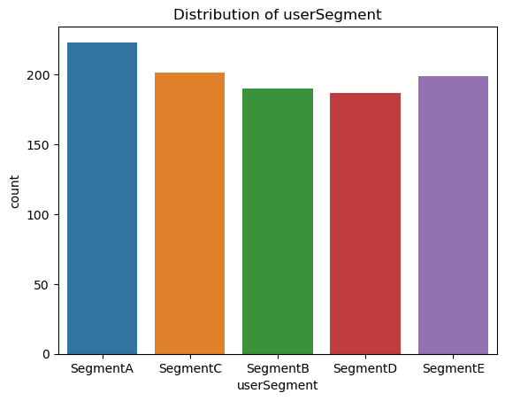

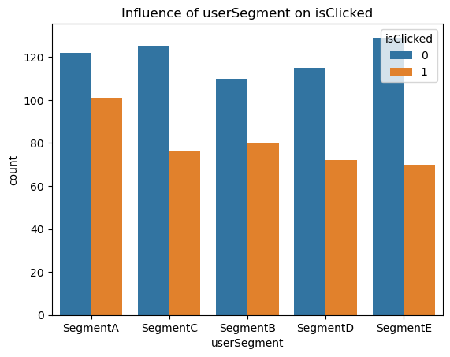

```python
import pandas as pd
import seaborn as sns
import matplotlib.pyplot as plt

# Assuming data is loaded as df
df = df_user_ad_engagement

# Check for missing values
print(df.info())

# Identify missing values in timeSpent column
missing_values_count = df['timeSpent'].isna().sum()
print(f"Number of missing values in 'timeSpent': {missing_values_count}")

# Handling missing values (for simplicity, we'll fill NaN in 'timeSpent' with median)
df['timeSpent'].fillna(df['timeSpent'].median(), inplace=True)

# Identify outliers for timeSpent using IQR
Q1 = df['timeSpent'].quantile(0.25)
Q3 = df['timeSpent'].quantile(0.75)
IQR = Q3 - Q1

# Outliers are values that fall below (Q1 - 1.5 * IQR) or above (Q3 + 1.5 * IQR)
outliers = df[(df['timeSpent'] < (Q1 - 1.5 * IQR)) | (df['timeSpent'] > (Q3 + 1.5 * IQR))]
print(f"Number of outliers in 'timeSpent': {len(outliers)}")
print(outliers[['userID', 'timeSpent']])

# Handling outliers (for simplicity, we'll replace outliers with median value)
df.loc[(df['timeSpent'] < (Q1 - 1.5 * IQR)) | (df['timeSpent'] > (Q3 + 1.5 * IQR)), 'timeSpent'] = df['timeSpent'].median()

# Visualizing userSegment distribution
sns.countplot(data=df, x='userSegment')
plt.title('Distribution of userSegment')
plt.show()

# Visualizing the influence of userSegment on isClicked
sns.countplot(data=df, x='userSegment', hue='isClicked')
plt.title('Influence of userSegment on isClicked')
plt.show()
```

### Summary:

The solution specifically identifies the number of missing values in the timeSpent column and the entries considered as outliers based on the IQR method. After identification, these missing values and outliers are handled appropriately. The subsequent visualizations provide insights into the distribution of the userSegment column and its influence on isClicked.

## Question 2

**Scenario**: You've been asked to evaluate the performance of different ad campaigns and their respective categories.

**Task**: Using the UserAdEngagement and AdCampaignInfo tables, identify the adCategory that has the second-highest average timeSpent for ads clicked (isClicked=1). Furthermore, find the adCategory where the maximum timeSpent on clicked ads is less than or equal to 300 seconds.

## Solution:

### Hints:

1. Join the UserAdEngagement and AdCampaignInfo tables on the adID column.
2. Use GROUP BY in combination with aggregate functions like AVG() to compute the average timeSpent and MAX() for each adCategory.
3. Utilize Common Table Expressions (CTE) or subqueries to determine the required ranks and conditions for the results.

```python
import sqlite3
import pandas as pd

df_user_ad = df  # the processed dataframe from question 1
df_ad_campaign = df_ad_campaign_info  # This should be replaced with your AdCampaignInfo dataframe

# Connect to an in-memory SQLite database
conn = sqlite3.connect(":memory:")

# Load dataframes into the SQLite database
df_user_ad.to_sql('UserAdEngagement', conn, index=False)
df_ad_campaign.to_sql('AdCampaignInfo', conn, index=False)

# SQL Query to answer the tasks
query_for_second_highest = """
WITH ClickedAds AS (
    SELECT aci.adCategory, AVG(uae.timeSpent) AS avgTimeSpent
    FROM UserAdEngagement uae
    JOIN AdCampaignInfo aci ON uae.adID = aci.adID
    WHERE uae.isClicked = 1
    GROUP BY aci.adCategory
),
RankedAds AS (
    SELECT adCategory, avgTimeSpent, RANK() OVER (ORDER BY avgTimeSpent DESC) AS rank
    FROM ClickedAds
)

SELECT adCategory AS SecondHighestAvgTimeCategory, avgTimeSpent
FROM RankedAds
WHERE rank = 2
"""

query_for_max_time_below_300 = """
WITH ClickedAds AS (
    SELECT aci.adCategory, MAX(uae.timeSpent) AS maxTimeSpent
    FROM UserAdEngagement uae
    JOIN AdCampaignInfo aci ON uae.adID = aci.adID
    WHERE uae.isClicked = 1
    GROUP BY aci.adCategory
)

SELECT adCategory AS MaxTimeBelow60sCategory, maxTimeSpent
FROM ClickedAds
WHERE maxTimeSpent <= 300
"""

result_second_highest = pd.read_sql(query_for_second_highest, conn)
result_max_time_below_60 = pd.read_sql(query_for_max_time_below_300, conn)

print("Second Highest Average Time Category:")
print(result_second_highest)

print("\nCategories with Max TimeSpent <= 300 seconds:")
print(result_max_time_below_60)

conn.close()
```

```
Second Highest Average Time Category:
  SecondHighestAvgTimeCategory  avgTimeSpent
0                          NFT     146.90099

Categories with Max TimeSpent <= 300 seconds:
  MaxTimeBelow60sCategory  maxTimeSpent
0                     Art         291.0
1             Electronics         289.0
2                 Fashion         284.0
3                    Food         289.0
4                     NFT         285.0
```

## Question 3

**Scenario**: There's a hypothesis that users from two specific segments, SegmentA and SegmentB, click on ads independently of each other.

**Task**: Calculate the probability that a randomly selected user from SegmentA clicks on an ad and a randomly selected user from SegmentB does not click on the same ad. Validate this probability using both the formula and the data in UserAdEngagement table.

## Solution:

### Hints:

1. Calculate the individual probabilities first: P(SegmentA clicks) and P(SegmentB does not click).
2. Since the events are assumed to be independent, their joint probability is the product of their individual probabilities.
3. Compare the derived probability with actual data.

```python
# Calculating individual probabilities
P_A_clicks = len(df[(df['userSegment'] == 'SegmentA') & (df['isClicked'] == 1)]) / len(df[df['userSegment'] == 'SegmentA'])
P_B_not_click = len(df[(df['userSegment'] == 'SegmentB') & (df['isClicked'] == 0)]) / len(df[df['userSegment'] == 'SegmentB'])

# Joint probability
joint_prob = P_A_clicks * P_B_not_click
print("Calculated joint probability:", joint_prob)

# Validating with data
actual_prob = len(df[(df['userSegment'] == 'SegmentA') & (df['isClicked'] == 1) &
                     (df['userSegment'].shift(-1) == 'SegmentB') & (df['isClicked'].shift(-1) == 0)]) / len(df)
print("Actual joint probability from data:", actual_prob)
```

```
Calculated joint probability: 0.26221383054047676
Actual joint probability from data: 0.007
```

## Question 4

**Scenario**: Considering that user engagement directly impacts ad revenue, there's an initiative to introduce an "Ad Feedback" button similar to the "like" button, allowing users to provide feedback on ads.

**Task**: Suggest potential advantages and pitfalls of introducing such a button. Furthermore, based on the UserAdEngagement dataset, propose key metrics to measure the effectiveness of this new feature.

## Solution:

### Hints:

1. Use the historical timeSpent data from the UserAdEngagement table as a proxy to user engagement.
2. Compute the correlation between the time a user spends on an ad and the likelihood of the ad being clicked.
3. Introduce hypothetical feedback data to model the potential impact of the "Ad Feedback" button.

### Potential Advantages:

- User Insight: Understand what type of ads resonate most with users.
- Algorithm Training: Improve ad-targeting algorithms based on feedback.
- Increased Engagement: Users might feel more involved and valued if they know their feedback is being taken into account.

### Potential Pitfalls:

- User Fatigue: Too much feedback seeking can irritate users.
- Misleading Feedback: Users might give feedback without much thought, leading to misleading insights.
- Implementation Challenges: Advertisers and brands might have concerns about negative feedback visibility.

### Analyzing the Effectiveness:

To measure the effectiveness of the "Ad Feedback" button, we'll take the following approach:

1. Hypothesize a new column in UserAdEngagement named feedback: This could be binary (1 for positive feedback, 0 for no feedback, and -1 for negative feedback).
2. Correlate Feedback with Ad Clicks and TimeSpent: We'd like to see if users who give positive feedback also spend more time on ads and are more likely to click them.

```
           isClicked  timeSpent  feedback
isClicked   1.000000   0.798834 -0.002532
timeSpent   0.798834   1.000000  0.046606
feedback   -0.002532   0.046606  1.000000
```

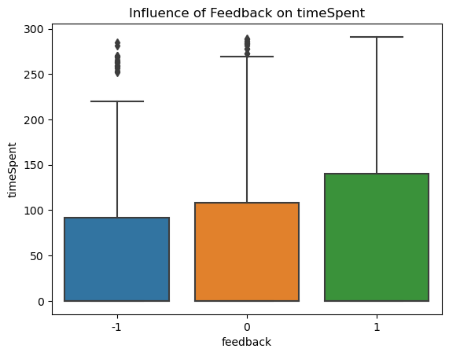

```python
import pandas as pd
import numpy as np
import seaborn as sns
import matplotlib.pyplot as plt

# Assuming df is the UserAdEngagement dataframe
# Introducing hypothetical feedback data
np.random.seed(42)  # for reproducibility
df['feedback'] = np.random.choice([1, 0, -1], df.shape[0], p=[0.3, 0.5, 0.2])

# Correlation analysis
correlation_matrix = df[['isClicked', 'timeSpent', 'feedback']].corr()

print(correlation_matrix)

# Visualization of feedback influence on timeSpent
sns.boxplot(data=df, x='feedback', y='timeSpent')
plt.title('Influence of Feedback on timeSpent')
plt.show()
```

### Summary:

The solution outlines potential advantages and pitfalls of introducing an "Ad Feedback" button. The hypothetical analysis using the UserAdEngagement dataset demonstrates how one might measure the effectiveness of this new feature by analyzing correlations and visualizations of user feedback with the time spent on ads and their click-through rate. The results can help inform decisions about the feature's implementation and potential impact.